# project1

Federico Acosta y Lara

1/29/2021

### Download data

```r
Url <- "https://d396qusza40orc.cloudfront.net/repdata%2Fdata%2Factivity.zip"
download.file(Url, destfile = "activity.zip", method = "curl")
unzip("activity.zip",exdir = "data")
```

## What is mean total number of steps taken per day?

1. Calculate the total number of steps taken per day

We group the data by date and calculate the sum of steps for each day.

```r
StepsDay <- summary_by(data = Data, formula = .~date, FUN=sum)
StepsDay <- StepsDay[,-3]
head(StepsDay, 10)
```

```
##          date steps.sum
## 1  2012-10-01        NA
## 2  2012-10-02       126
## 3  2012-10-03     11352
## 4  2012-10-04     12116
## 5  2012-10-05     13294
## 6  2012-10-06     15420
## 7  2012-10-07     11015
## 8  2012-10-08        NA
## 9  2012-10-09     12811
## 10 2012-10-10      9900
```

2. Make a histogram of the total number of steps taken each day.

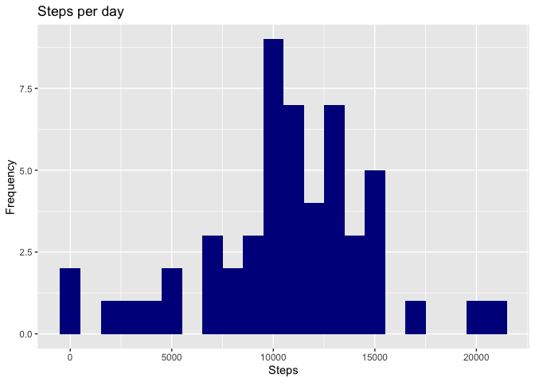

```r
ggplot(StepsDay, aes(x = steps.sum)) +
    geom_histogram(fill = "darkblue", binwidth = 1000) +
    labs(title = "Steps per day", x = "Steps", y = "Frequency")
```

3. Calculate and report the mean and median of the total number of steps taken per day

**Step per day mean =** 1.0766189^{4} **Step per day median =** 10765

## What is the average daily activity pattern?

1. Make a time series plot (i.e. 𝚝𝚢𝚙𝚎 = “𝚕”) of the 5-minute interval (x-axis) and the average number of steps taken, averaged across all days (y-axis)

```r
Interval <- dplyr::group_by(Data, interval)
StepsInterval <- dplyr::summarise(Interval, steps = mean(steps, na.rm=T))
```

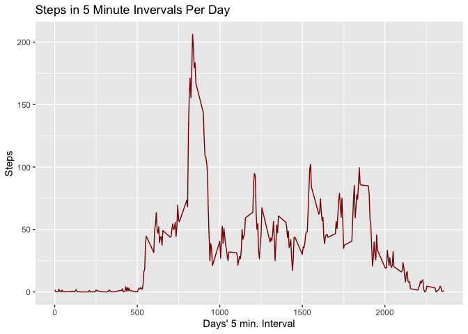

```r
ggplot(StepsInterval,
       aes(x=interval, y=steps)) +
  geom_line(color="darkred") +
  xlab("Days' 5 min. Interval") + ylab("Steps") +
  ggtitle("Steps in 5 Minute Invervals Per Day")
```

2. Which 5-minute interval, on average across all the days in the dataset, contains the maximum number of steps?

The interval wich contains the maximum number of step is 835 . The number of steps is 206.1698113